# Final Project Report: WWII War Economies

### 1.4: Visualising each category of raw materials in one visual (figure 1)

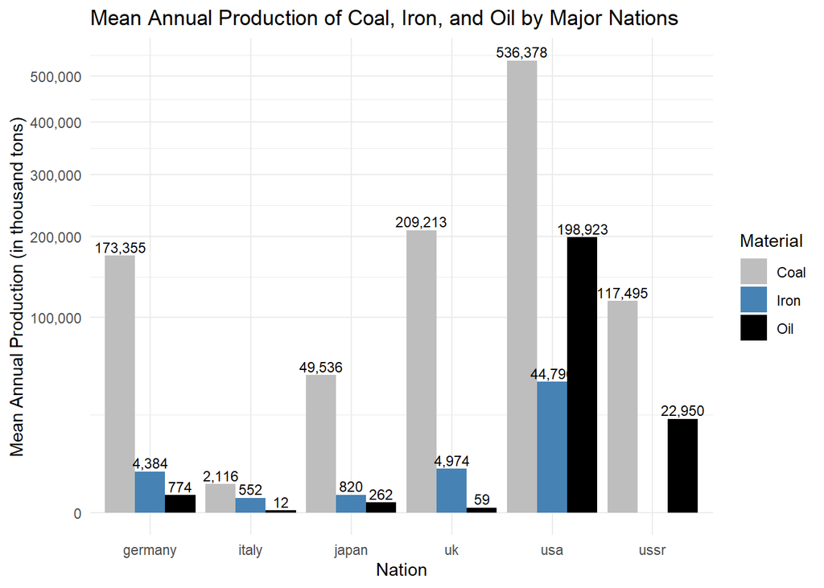

```r
# Filter and reshape the data to long format
production_long <- raw_materials_data %>%
  filter(country %in% major_nations) %>%
  select(country, coal_produced, iron_produced, oil_produced) %>%
  pivot_longer(
    cols = c(coal_produced, iron_produced, oil_produced),
    names_to = "material",
    values_to = "amount"
  )

# Calculate mean annual production per country and material
mean_production <- production_long %>%
  group_by(country, material) %>%
  summarise(mean_annual = mean(amount, na.rm = TRUE), .groups = "drop") %>%
  mutate(mean_annual = mean_annual / 1)  # Convert to millions for better scale


ggplot(mean_production, aes(x = country, y = mean_annual, fill = material)) +
  geom_col(position = "dodge") +
  geom_text(
  aes(label = comma(mean_annual)),
  position = position_dodge(width = 0.9),
  vjust = -0.3,
  size = 3
) +
  scale_y_continuous(trans = "sqrt", labels = comma_format()) +
  scale_fill_manual(
    values = c("coal_produced" = "grey",
               "iron_produced" = "steelblue",
               "oil_produced" = "black"),
    labels = c("Coal", "Iron", "Oil")
  ) +
  labs(
    title = "Mean Annual Production of Coal, Iron, and Oil by Major Nations",
    x = "Nation",
    y = "Mean Annual Production (in thousand tons)",
    fill = "Material"
  ) +
  theme_minimal()
```

Note that there was no data available in the source on USSR iron production, which is therefore absent in this data set.

### 1.5: Mean Annual Production of Coal, Iron, and Oil by Major Nations + important Allies/Occupied territories

### Loading data set with production of important allies/occupied areas

```r
data_raw_materials_with_allies <- read_csv("data/raw materials w allies 2.1.csv")
str(data_raw_materials_with_allies)
```

```
## spc_tbl_ [42 × 5] (S3: spec_tbl_df/tbl_df/tbl/data.frame)
##  $ year         : num [1:42] 1939 1940 1941 1942 1943 ...
##  $ country      : chr [1:42] "gerausrom" "gerausrom" "gerausrom" "gerausrom" ...
##  $ coal_produced: chr [1:42] "174687" "173043" "172075" "172633" ...
##  $ iron_produced: chr [1:42] "4978" "6344" "5770" "5187" ...
##  $ oil_produced : chr [1:42] "7124" "7279" "7007" "7280" ...
##  - attr(*, "spec")=
##   .. cols(
##   ..   year = col_double(),
##   ..   country = col_character(),
##   ..   coal_produced = col_character(),
##   ..   iron_produced = col_character(),
##   ..   oil_produced = col_character()
##   .. )
##  - attr(*, "problems")=<externalptr>
```

```r
data_raw_materials_with_allies$year <- as.integer(data_raw_materials_with_allies$year)
data_raw_materials_with_allies$country <- as.character(data_raw_materials_with_allies$country)
data_raw_materials_with_allies$coal_produced <- as.numeric(data_raw_materials_with_allies$coal_produced)
data_raw_materials_with_allies$iron_produced <- as.numeric(data_raw_materials_with_allies$iron_produced)
data_raw_materials_with_allies$oil_produced <- as.numeric(data_raw_materials_with_allies$oil_produced)
str(data_raw_materials_with_allies)
```

```
## spc_tbl_ [42 × 5] (S3: spec_tbl_df/tbl_df/tbl/data.frame)
##  $ year         : int [1:42] 1939 1940 1941 1942 1943 1944 1945 1939 1940 1941 ...
##  $ country      : chr [1:42] "gerausrom" "gerausrom" "gerausrom" "gerausrom" ...
##  $ coal_produced: num [1:42] 174687 173043 172075 172633 174338 ...
##  $ iron_produced: num [1:42] 4978 6344 5770 5187 5195 ...
##  $ oil_produced : num [1:42] 7124 7279 7007 7280 7087 ...
##  - attr(*, "spec")=
##   .. cols(
##   ..   year = col_double(),
##   ..   country = col_character(),
##   ..   coal_produced = col_character(),
##   ..   iron_produced = col_character(),
##   ..   oil_produced = col_character()
##   .. )
##  - attr(*, "problems")=<externalptr>
```

### 1.6: Mean Annual Production of Raw Materials by Major Nations in WWII, including Axis allies and Occupied Areas (figure 2)

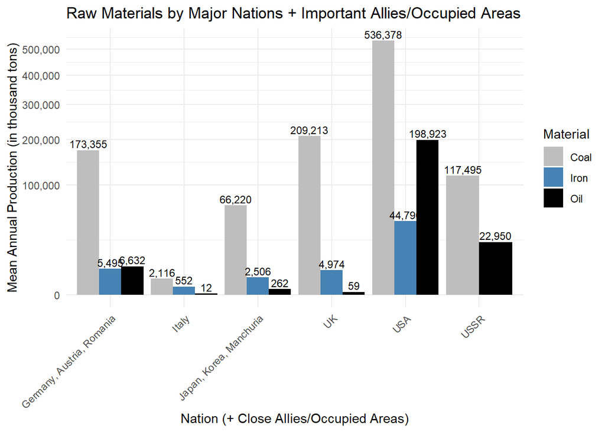

```r
# Create a custom names for countries
country_groups <- c(
  gerausrom = "Germany, Austria, Romania",
  japkrmanchu = "Japan, Korea, Manchuria",
  usa = "USA",
  uk = "UK",
  ussr = "USSR",
  italy = "Italy"
)

# Filter only countries in the grouping
grouped_data <- data_raw_materials_with_allies %>%
  filter(country %in% names(country_groups)) %>%
  mutate(group = country_groups[country])

# Convert to long format and summarise mean production
grouped_long <- grouped_data %>%
  select(group, coal_produced, iron_produced, oil_produced) %>%
  pivot_longer(
    cols = c(coal_produced, iron_produced, oil_produced),
    names_to = "material",
    values_to = "amount"
  ) %>%
  filter(!is.na(amount)) %>%  # 🔧 Drop rows with NA production values
  group_by(group, material) %>%
  summarise(mean_annual = mean(amount), .groups = "drop")  # No need for na.rm anymore

# Plot
ggplot(grouped_long, aes(x = group, y = mean_annual, fill = material)) +
  geom_col(position = "dodge") +
  geom_text(
    aes(label = comma(mean_annual)),
    position = position_dodge(width = 0.9),
    vjust = -0.3,
    size = 3
  ) +
  scale_y_continuous(trans = "sqrt", labels = comma_format()) +
  scale_fill_manual(
    values = c("coal_produced" = "grey",
               "iron_produced" = "steelblue",
               "oil_produced" = "black"),
    labels = c("Coal", "Iron", "Oil")
  ) +
  labs(
    title = "Raw Materials by Major Nations + Important Allies/Occupied Areas",
    x = "Nation (+ Close Allies/Occupied Areas)",
    y = "Mean Annual Production (in thousand tons)",
    fill = "Material"
  ) +
  theme_minimal() +
  theme(axis.text.x = element_text(angle = 45, hjust = 1))
```

## 2: Production of war material of Major Nations (figures 3 and 4)

### 2.1: Tank Production

#### Loading the data set for tank production

```r
tank_data <- read_csv("data/Tank Production Sheet 1.0.csv")
str(tank_data)
```

```
## spc_tbl_ [35 × 3] (S3: spec_tbl_df/tbl_df/tbl/data.frame)
##  $ year          : num [1:35] 1939 1939 1939 1939 1939 ...
##  $ country       : chr [1:35] "germany" "japan" "usa" "britain" ...
##  $ tanks_produced: chr [1:35] "1300" "-" "-" "969" ...
##  - attr(*, "spec")=
##   .. cols(
##   ..   year = col_double(),
##   ..   country = col_character(),
##   ..   tanks_produced = col_character()
##   .. )
##  - attr(*, "problems")=<externalptr>
```

```r
tank_data$year <- as.integer(tank_data$year)
tank_data$country <- as.character(tank_data$country)
tank_data$tanks_produced <- as.numeric(tank_data$tanks_produced)
str(tank_data)
```

```
## spc_tbl_ [35 × 3] (S3: spec_tbl_df/tbl_df/tbl/data.frame)
##  $ year          : int [1:35] 1939 1939 1939 1939 1939 1940 1940 1940 1940 1940 ...
##  $ country       : chr [1:35] "germany" "japan" "usa" "britain" ...
##  $ tanks_produced: num [1:35] 1300 NA NA 969 2950 ...
##  - attr(*, "spec")=
##   .. cols(
##   ..   year = col_double(),
##   ..   country = col_character(),
##   ..   tanks_produced = col_character()
##   .. )
##  - attr(*, "problems")=<externalptr>
```

### 2.2: Comparing tank production of Major Nations (figure 3)

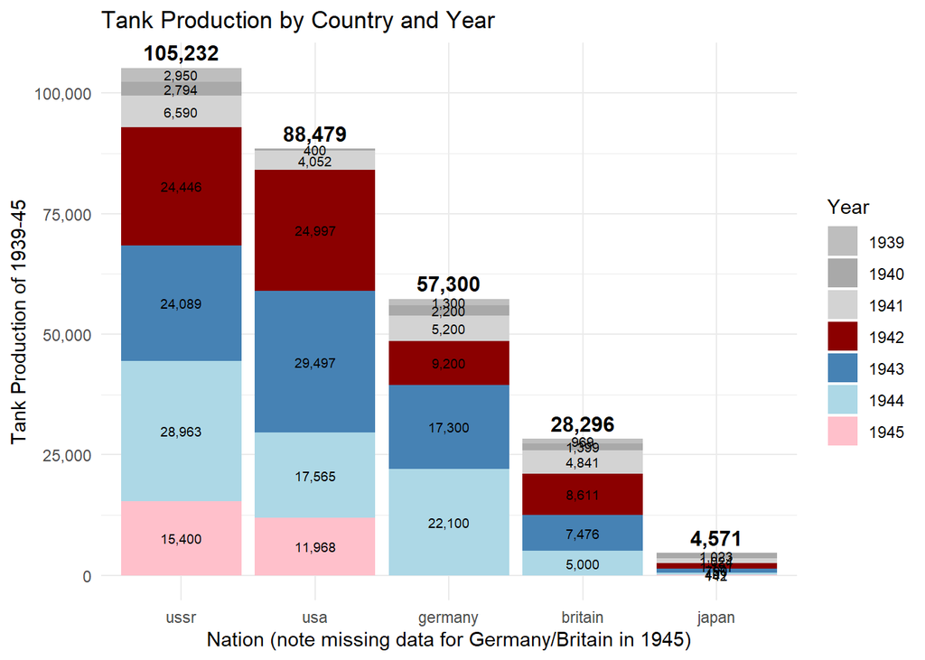

```r
tank_summary <- tank_data %>%
  filter(!is.na(tanks_produced)) %>%
  mutate(year = as.factor(year)) %>%
  group_by(country, year) %>%
  summarise(total_tanks = sum(tanks_produced, na.rm = TRUE), .groups = "drop")

tank_summary <- tank_summary %>%
  group_by(country) %>%
  mutate(total_all_years = sum(total_tanks)) %>%
  ungroup() %>%
  mutate(country = reorder(country, -total_all_years))

year_colors <- c(
  "1939" = "grey",
  "1940" = "darkgrey",
  "1941" = "lightgrey",
  "1942" = "darkred",
  "1943" = "steelblue",
  "1944" = "lightblue",
  "1945" = "pink"
)
total_per_country <- tank_summary %>%
  group_by(country) %>%
  summarise(total_all_years = sum(total_tanks), .groups = "drop") %>%
  mutate(country = factor(country, levels = levels(tank_summary$country)))

ggplot(tank_summary, aes(x = country, y = total_tanks, fill = year)) +
  geom_col() +
  geom_text(aes(label = comma(total_tanks)),
            position = position_stack(vjust = 0.5),
            size = 2.5, color = "black") +
  geom_text(
    data = total_per_country,
    aes(x = country, y = total_all_years, label = comma(total_all_years)),
    vjust = -0.5, size = 4, fontface = "bold",
    inherit.aes = FALSE
  ) +
  scale_fill_manual(values = year_colors) +
  scale_y_continuous(labels = comma_format()) +
  labs(
    title = "Tank Production by Country and Year",
    x = "Nation (note missing data for Germany/Britain in 1945)",
    y = "Tank Production of 1939-45",
    fill = "Year"
  ) +
  theme_minimal()
```

I’ve put the first war years in similar grey colours, so that the relatively small production of these years may be viewed in contrast to the much bigger production of the later war years.

## 2.3: Production of Military Aircraft of the Major Nations (figure 4)

```r
aircraft_data <- read_csv("data/Aircraft Production Sheet 1.0.csv")
str(aircraft_data)
```

```
## spc_tbl_ [35 × 3] (S3: spec_tbl_df/tbl_df/tbl/data.frame)
##  $ year             : num [1:35] 1939 1939 1939 1939 1939 ...
##  $ country          : chr [1:35] "germany" "japan" "usa" "britain" ...
##  $ aircraft_produced: num [1:35] 8295 4467 5856 7940 10382 ...
##  - attr(*, "spec")=
##   .. cols(
##   ..   year = col_double(),
##   ..   country = col_character(),
##   ..   aircraft_produced = col_double()
##   .. )
##  - attr(*, "problems")=<externalptr>
```

```r
aircraft_data$year <- as.integer(aircraft_data$year)
aircraft_data$country <- as.character(aircraft_data$country)
aircraft_data$aircraft_produced <- as.numeric(aircraft_data$aircraft_produced)

str(aircraft_data)
```

```
## spc_tbl_ [35 × 3] (S3: spec_tbl_df/tbl_df/tbl/data.frame)
##  $ year             : int [1:35] 1939 1939 1939 1939 1939 1940 1940 1940 1940 1940 ...
##  $ country          : chr [1:35] "germany" "japan" "usa" "britain" ...
##  $ aircraft_produced: num [1:35] 8295 4467 5856 7940 10382 ...
##  - attr(*, "spec")=
##   .. cols(
##   ..   year = col_double(),
##   ..   country = col_character(),
##   ..   aircraft_produced = col_double()
##   .. )
##  - attr(*, "problems")=<externalptr>
```

### Military Aircraft Production by Country and Year (Figure 4)

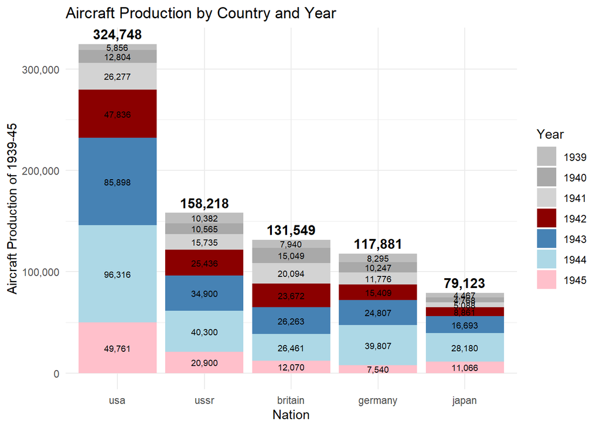

```r
aircraft_summary <- aircraft_data %>%
  filter(!is.na(aircraft_produced)) %>%
  mutate(year = as.factor(year)) %>%
  group_by(country, year) %>%
  summarise(total_aircraft = sum(aircraft_produced, na.rm = TRUE), .groups = "drop")

aircraft_summary <- aircraft_summary %>%
  group_by(country) %>%
  mutate(total_all_years = sum(total_aircraft)) %>%
  ungroup() %>%
  mutate(country = reorder(country, -total_all_years))

year_colors <- c(
  "1939" = "grey",
  "1940" = "darkgrey",
  "1941" = "lightgrey",
  "1942" = "darkred",
  "1943" = "steelblue",
  "1944" = "lightblue",
  "1945" = "pink"
)
total_per_country <- aircraft_summary %>%
  group_by(country) %>%
  summarise(total_all_years = sum(total_aircraft), .groups = "drop") %>%
  mutate(country = factor(country, levels = levels(aircraft_summary$country)))

ggplot(aircraft_summary, aes(x = country, y = total_aircraft, fill = year)) +
  geom_col() +
  geom_text(aes(label = comma(total_aircraft)),
            position = position_stack(vjust = 0.5),
            size = 2.5, color = "black") +
  geom_text(
    data = total_per_country,
    aes(x = country, y = total_all_years, label = comma(total_all_years)),
    vjust = -0.5, size = 4, fontface = "bold",
    inherit.aes = FALSE
  ) +
  scale_fill_manual(values = year_colors) +
  scale_y_continuous(labels = comma_format()) +
  labs(
    title = "Aircraft Production by Country and Year",
    x = "Nation",
    y = "Aircraft Production of 1939-45",
    fill = "Year"
  ) +
  theme_minimal()
```